# Анализ и визуализация текстовых данных

2025-01-10

Курс магистратуры “Компьютерная лингвистика” НИУ ВШЭ

- Читает Ольга Ляшевская [page](https://www.hse.ru/staff/olesar/) email
- Об оценках - [link](https://www.hse.ru/edu/courses/912654221)
- О экзаменационном проекте - link
- Ведомость - [link](https://docs.google.com/spreadsheets/d/16rZMgKvT0Az24KXLrjz7PQ2n1f-SUx2Teg382_BvNl8)
- Опросник - [link](https://forms.gle/YaujDy3EiMMvZVhdA)
- Базовый учебник - [Поздняков 2024](https://pozdniakov.github.io/tidy_stats/)

### Расписание

[output not shown]

### Домашние задания

Сдаются на почту gmail `neurolong@` с темой с темой da4cl накануне семинара

- HW1 Rmd html – дедлайн 27.01
- HW2 Rmd html – дедлайн 03.02
- HW3 Rmd html – дедлайн 23.02
- HW4 Rmd html – дедлайн 16.03
- HW5 Rmd html – дедлайн 12.05

### Чекпойнты по проекту

- Идея для проекта – дедлайн 17.03 до семинара  
  сформулировать тему и гипотезу исследования для экзаменационного проекта (напишите преподавателю, а затем заполните вкладку “Проекты” в ведомости). Желательно предложить 2 идеи для исследования (если вы еще не согласовали ее раньше)
- Чекпойнт по данным – драфт датасета (не менее 100 строк для корпусных данных, объем экспериментальных и др. данных обсуждается с преподавателем) – начало апреля
- Описательная статистика по данным – 12 мая
- Драфт анализа данных – 2 июня

### Литература

Hvitfeldt, Emil. Feature Engineering A-Z (https://feaz-book.com/)  
Wickham, H. R for data science: import, tidy, transform, visualize, and model data. 2017 (https://r4ds.hadley.nz/)  
Wickham, H. ggplot2: elegant graphics for data analysis. 2009 (https://ggplot2-book.org)  
Tabachnick, Barbara G., & Linda S. Fidell. Using multivariate statistics. 2014 (https://hisp.htmi.ch/pluginfile.php/77114/mod_resource/content/0/Using%20Multivariate%20Statistics%20%28Tabachnick%20and%20Fidell%29.pdf)  
Silge, Julia, & David Robinson. Text Mining with R: A Tidy Approach. O’Reilly Media, 2017 (https://www.tidytextmining.com/)  
Levshina N. How to do Linguistics with R: Data exploration and statistical analysis. 2015.  
Baayen, R. H. Analyzing linguistic data: a practical introduction to statistics using R. 2014.  
Gries St. T. Statistics for Linguistics with R. 3rd ed. 2021.  
Поздняков И. Анализ данных и статистика в R (https://pozdniakov.github.io/tidy_stats) Алиева О. Компьютерный анализ текста в R. 2023 (https://locusclassicus.github.io/text_analysis_2023)  
Продвинутые главы:  
Мороз Г. Введение в анализ данных на R для гуманитарных и социальных наук. 2022 (https://agricolamz.github.io/daR4hs)  
Harney, H. L. (2016). Bayesian Inference: Data Evaluation and Decisions (Vol. 2nd ed). Springer.  
McElreath, R. (2016). Statistical Rethinking: A Bayesian Course with Examples in R and Stan. eBook (https://github.com/rmcelreath/stat_rethinking_2024)  
Nicenboim, Bruno, Daniel J. Schad, and Shravan Vasishth. An Introduction to Bayesian Data Analysis for Cognitive Science. 2024 (https://bruno.nicenboim.me/bayescogsci/)

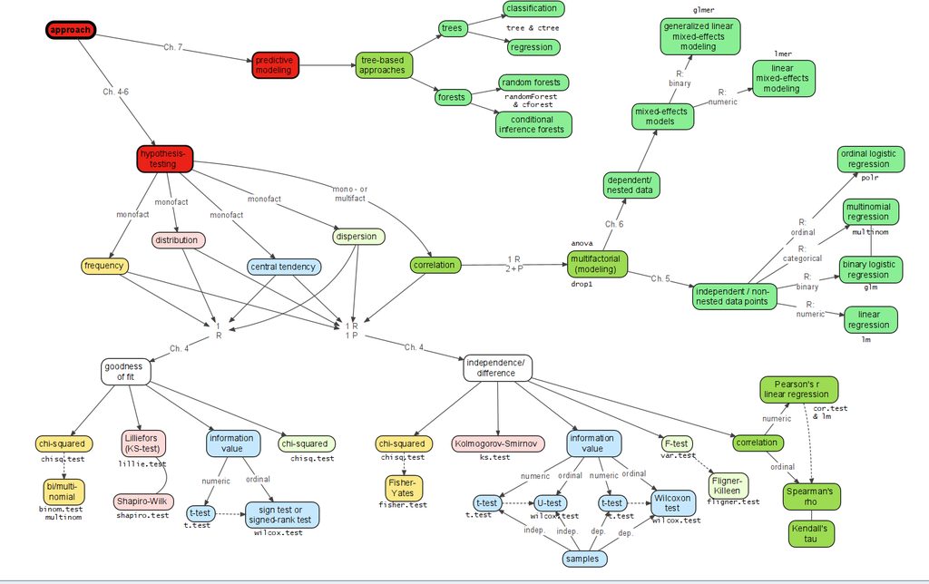